# DS 807 Take Home Exam

Aleena

```r
library(kableExtra)
library(MASS)
library(ISLR)
library(factoextra)
library(cluster)
library(dendextend)
```

```r
library(tidyverse)
library(tidytext)
library(wordcloud)
library(wordcloud2)
library(textdata)
library(igraph)
library(ggraph)
library(widyr)
library(tm)
library(SnowballC)
library(randomForest)
library(caret)
library(topicmodels)
library(klaR)
library(dbscan)
library(dplyr)
```

## Take Home Exam Guidelines

#### Purpose:

- Learning Outcomes measured in this assignment: LO1 to LO6

#### Criteria:

- For this exam, you are expected to work alone.
- Submission: You need to upload the knitted document on Canvas.
- Points distribution:

|  | R code | Decision/Why | Communication of findings |
| --- | --- | --- | --- |
| Percentage of Assigned Points | 30% | 35% | 35% |
| If no R code is required |  | 50% | 50% |

- **Decision/why?**: Explain your reasoning behind your choice of the procedure, set of variables and such for the question.
  - Explain why you use the procedure/model/variable
  - To exceed this criterion, describe steps taken to implement the procedure in a non technical way.

## Exam

### Data Sets

For this exam, you will be working with 2 different data sets.

1. Data set for the first part: We will be working with emotion detection for tweets data set. This is a shorter version of [this data set](https://www.kaggle.com/datasets/pashupatigupta/emotion-detection-from-text) Our version is limited in terms of number of tweets, and has the following columns:
   - tweet_id
   - sentiment
   - content

**Notice that these are real tweets, they may include offensive language**

```r
data1=read_csv("https://unh.box.com/shared/static/548gdgan941coart2jmsmkrultg2rqn8.csv")
head(data1)
```

```
## # A tibble: 6 × 3
##   tweet_id sentiment content
##      <dbl> <chr>     <chr>
## 1        1 empty     @tiffanylue i know  i was listenin to bad habit earlier an…
## 2        2 sadness   Layin n bed with a headache  ughhhh...waitin on your call.…
## 3        3 neutral   No want work
## 4        4 fun       http://twitpic.com/66ltb - Finito~! Hunk Ah Hunk of Burnin…
## 5        5 neutral   dont go... im sorry for disappointing you
## 6        6 worry     thoughts out to Vicki (MOM) who just hit a deer in her Sta…
```

2. Data set for the second part is available below. For more information, please visit https://www.kaggle.com/rohan0301/unsupervised-learning-on-country-data
- Variables are:
  - country: Name of the country
  - child_mort: Death of children under 5 years of age per 1000 live births
  - exports: Exports of goods and services per capita. Given as %age of the GDP per capita
  - health: Total health spending per capita. Given as %age of GDP per capita
  - imports: Imports of goods and services per capita. Given as %age of the GDP per capita
  - Income: Net income per person
  - Inflation: The measurement of the annual growth rate of the Total GDP
  - life_expec: The average number of years a new born child would live if the current mortality patterns are to remain the same
  - total_fer: The number of children that would be born to each woman if the current age-fertility rates remain the same
  - gdpp:The GDP per capita. Calculated as the Total GDP divided by the total population.

```r
data2=read_csv("https://unh.box.com/shared/static/aevprtu4pz8sv883mrp5watcgxltikmc.csv")
data2 = subset(data2, select = -c(country) )
data2 <- scale(data2) %>%na.omit(data2)
head(data2)
```

```
##      child_mort     exports      health     imports      income  inflation
## [1,]  1.2876597 -1.13486665  0.27825140 -0.08220771 -0.80582187  0.1568645
## [2,] -0.5373329 -0.47822017 -0.09672528  0.07062429 -0.37424335 -0.3114109
## [3,] -0.2720146 -0.09882442 -0.96317624 -0.63983800 -0.22018227  0.7869076
## [4,]  2.0017872  0.77305618 -1.44372888 -0.16481961 -0.58328920  1.3828944
## [5,] -0.6935483  0.16018613 -0.28603389  0.49607554  0.10142673 -0.5999442
## [6,] -0.5894047 -0.81019144  0.46756001 -1.27594958  0.08067776  1.2409928
##      life_expec   total_fer        gdpp
## [1,] -1.6142372  1.89717646 -0.67714308
## [2,]  0.6459238 -0.85739418 -0.48416709
## [3,]  0.6684130 -0.03828924 -0.46398018
## [4,] -1.1756985  2.12176975 -0.51472026
## [5,]  0.7021467 -0.54032130 -0.04169175
## [6,]  0.5897009 -0.38178486 -0.14535428
```

Part I: Text Mining (45 points total)

1. (10 points) Explain why we do text mining, i.e., what insights we can gain by sentiment analysis or topic modeling this particular data. Be specific to the data in hand.

**Text mining is a method of analyzing a large dataset in investigating hidden information. These details help us in answering issues such as why we have a specific feeling in a given tweet, as well as grouping tweets into distinct categories. The ultimate outcomes of text analysis are unaffected by our emotions or decisions.**

**Sentiment analysis or topic modelling is a method which helps us to group text into different topics and help us to find out the associated sentiment like is it positive or negative or neutral.Doing sentiment analysis in the given tweet helps us to find the opinion of public about various topics.**

2. (10 points) Data prep:
- Tokenize the data set by word and remove stop words.
- Arrange the words in descending order by frequency. Based on the most frequent words, do you need to add more words to stop words? Why/Why not?

**Yes, additional stopwords are needed since words like twitpic.com,tinyurl.com,lt,quot,,bgt,gt,mitchelmusso,xx make little sense and are often used.**

- *If necessary anti_join the new stop words.* Visualize the word counts. Did you need to filter by frequency, or look at some `top` words? Why/Why not? What does this plot tell you?

**Yes, I utilized the top 30 terms to discover the most often used words. It will give all words if it is not filtered, which will make it congested. Looking at the narrative, I realized that more terms like http and twitter needed to be removed.** **People seem to be tweeting more about how their day is going based on the top 30 terms.** **How they felt on a given day, as well as their concerns and worry. The top three terms are day, I’m, and time, indicating that individuals are tweeting about their day.**

```r
custom_stop_words <- tribble(
  # Column names should match stop_words
  ~word, ~lexicon,
  "twitpic.com", "CUSTOM",
  "tinyurl.com", "CUSTOM",
  "lt", "CUSTOM",
  "quot", "CUSTOM",
  "ï", "CUSTOM",
  "bgt", "CUSTOM",
  "gt", "CUSTOM",
  "mitchelmusso", "CUSTOM",
  "xx", "CUSTOM",
 "dai", "CUSTOM",
 "amp", "CUSTOM",
)
```

```r
text_tidy=data1 %>%
  unnest_tokens(word, content) %>%
  anti_join(stop_words) %>%
  anti_join(custom_stop_words)%>%
  count(word, sort=TRUE)%>%
  arrange(desc(n))
text_tidy
```

```
## # A tibble: 28,877 × 2
##    word      n
##    <chr> <int>
##  1 day     955
##  2 http    778
##  3 im      746
##  4 time    662
##  5 lol     645
##  6 miss    632
##  7 home    596
##  8 sad     576
##  9 2       557
## 10 love    540
## # … with 28,867 more rows
```

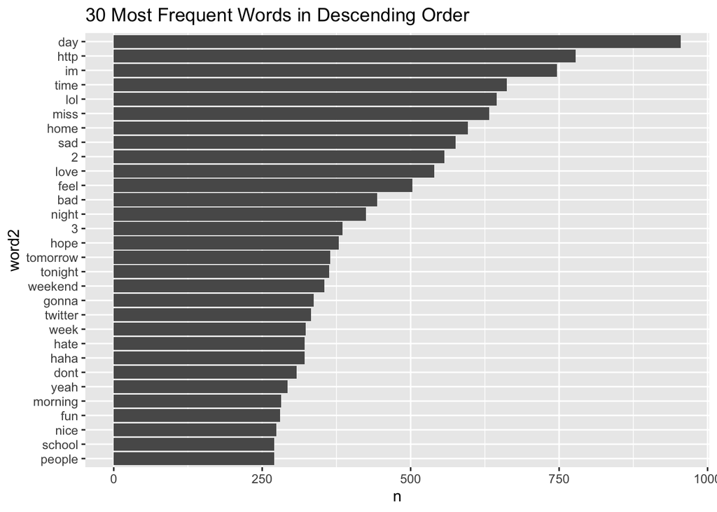

```r
word_counts <- text_tidy %>%
  #count(word) %>%
  mutate(word2 = fct_reorder(word, n))%>%
  top_n(30,n)

ggplot(word_counts, aes(x = word2, y = n)) +
  geom_col(show.legend=FALSE) +
  coord_flip() +
  ggtitle("30 Most Frequent Words in Descending Order")
```

```r
custom_stop_words1 <- tribble(
  # Column names should match stop_words
  ~word, ~lexicon,
  "http", "CUSTOM",
  "twitter", "CUSTOM",
  )
text_tidy1=data1 %>%
  unnest_tokens(word, content) %>%
  anti_join(stop_words) %>%
  anti_join(custom_stop_words)%>%
  anti_join(custom_stop_words1)%>%
count(word, sort=TRUE)%>%
  arrange(desc(n))
text_tidy1
```

```
## # A tibble: 28,875 × 2
##    word      n
##    <chr> <int>
##  1 day     955
##  2 im      746
##  3 time    662
##  4 lol     645
##  5 miss    632
##  6 home    596
##  7 sad     576
##  8 2       557
##  9 love    540
## 10 feel    503
## # … with 28,865 more rows
```

```r
#counting words was already done at text_tidy1
word_counts1 <- text_tidy1 %>%
  mutate(word2 = fct_reorder(word, n))%>%
  top_n(30,n)
word_counts1
```

```
## # A tibble: 30 × 3
##    word      n word2
##    <chr> <int> <fct>
##  1 day     955 day
##  2 im      746 im
##  3 time    662 time
##  4 lol     645 lol
##  5 miss    632 miss
##  6 home    596 home
##  7 sad     576 sad
##  8 2       557 2
##  9 love    540 love
## 10 feel    503 feel
## # … with 20 more rows
```

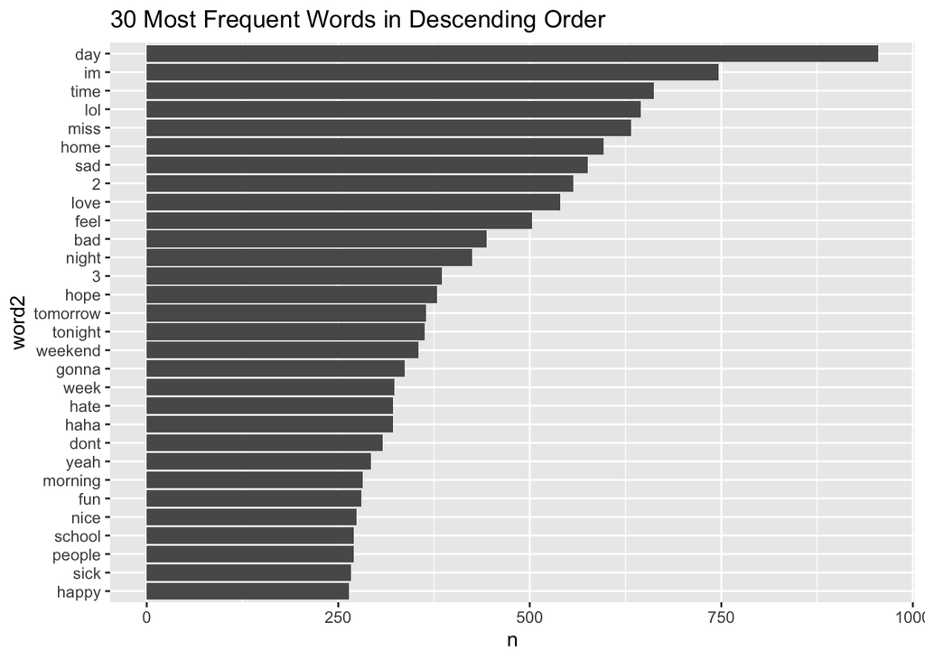

```r
ggplot(word_counts1, aes(x = word2, y = n)) +
  geom_col(show.legend=FALSE) +
  coord_flip() +
  ggtitle("30 Most Frequent Words in Descending Order")
```

3. (10 points) Sentiment Analysis: Choose a sentiment library and perform a sentiment analysis, i.e., join the data with sentiments, count sentiments, and plot sentiments. What does your analysis tells you?

```r
#counting words was already done at text_tidy1
sentiment_title = text_tidy1 %>%
  inner_join(get_sentiments("loughran"))%>%
  arrange(desc(n))
sentiment_title
```

```
## # A tibble: 631 × 3
##    word        n sentiment
##    <chr>   <int> <chr>
##  1 miss      632 negative
##  2 bad       444 negative
##  3 happy     264 positive
##  4 poor      184 negative
##  5 missed    174 negative
##  6 lost      171 negative
##  7 late      111 negative
##  8 wrong      89 negative
##  9 excited    88 positive
## 10 break      87 negative
## # … with 621 more rows
```

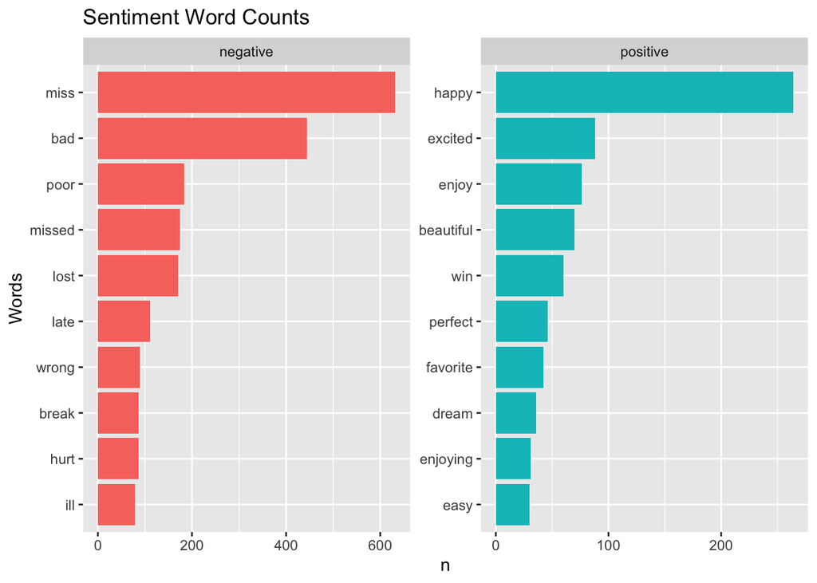

```r
sentiment_title2 = sentiment_title %>%
  filter(sentiment %in% c("positive", "negative"))
  sent_count =  sentiment_title2 %>%
  group_by(sentiment) %>%
  top_n(10, n) %>%
  ungroup() %>%
  mutate(word2=fct_reorder(word, n))

ggplot(sent_count, aes(x=word2, y=n, fill=sentiment)) +
  geom_col(show.legend=FALSE)+
  facet_wrap(~sentiment, scales="free")+
  coord_flip()+
  labs(title = "Sentiment Word Counts", x="Words")
```

**This plot indicates that negative terms occur in reviews more frequently than positive words. This means that there are most certainly more negative ratings in this data set than positive reviews. The most negative word is miss, whereas the most positive word is happy. Miss is the most commonly used word when it comes to sentiment. This lexicon does an excellent job of categorizing words into the appropriate categories.**

4. (10 points) Topic Modeling: Carry out a topic model with $k$.
   - Why did you choose this particular $k$?

**My k is 2.**

**I tried running LDA model with k=3 since my Perplexity graph had the least perplexity at 3.But my LDA topic didn’t look conviencing as 3rd topic was almost similar to first two topics. So i decided to go with k=2 which gives me an idea of topics.**

```
- Investigate the beta matrix for your model. What are the top 10 words for each topic?
```

```r
tweet_sentence=data1 %>%
  unnest_tokens(output=sentence, token = "sentences", input = content)
```

```r
tweet_tokens = tweet_sentence %>%
  unnest_tokens(output = word, token = "words", input=sentence) %>%
  anti_join(stop_words) %>%
  anti_join(custom_stop_words)%>%
  anti_join(custom_stop_words1)%>%
  mutate(word = wordStem(word))
tweet_tokens
```

```
## # A tibble: 111,706 × 3
##    tweet_id sentiment word
##       <dbl> <chr>     <chr>
##  1        1 empty     tiffanylu
##  2        1 empty     listenin
##  3        1 empty     bad
##  4        1 empty     habit
##  5        1 empty     earlier
##  6        1 empty     start
##  7        1 empty     freakin
##  8        2 sadness   layin
##  9        2 sadness   bed
## 10        2 sadness   headach
## # … with 111,696 more rows
```

```r
tweet_matrix = tweet_tokens %>%
  count(sentiment, word) %>%
  cast_dtm(document=sentiment, term=word,
           value=n, weighting=tm::weightTf)
tweet_matrix
```

```
## <<DocumentTermMatrix (documents: 13, terms: 25147)>>
## Non-/sparse entries: 45722/281189
## Sparsity           : 86%
## Maximal term length: 66
## Weighting          : term frequency (tf)
```

```r
ap_lda=LDA(tweet_matrix, k=3, control=list(seed=1234))
ap_lda
```

```
## A LDA_VEM topic model with 3 topics.
```

```r
lda_topics=tidy(ap_lda, matrix="beta")
lda_topics
```

```
## # A tibble: 75,441 × 3
##    topic term       beta
##    <int> <chr>     <dbl>
##  1     1 _hayl 1.75e-  5
##  2     2 _hayl 1.85e-196
##  3     3 _hayl 6.10e-209
##  4     1 110   1.75e-  5
##  5     2 110   1.67e-197
##  6     3 110   2.46e-208
##  7     1 3     3.20e-  3
##  8     2 3     2.78e-  3
##  9     3 3     4.01e-  3
## 10     1 35    1.05e-  4
## # … with 75,431 more rows
```

```r
lda_top_terms = lda_topics %>%
  group_by(topic) %>%
  top_n(10, beta)%>%
  ungroup() %>%
  arrange(topic, beta)
lda_top_terms
```

```
## # A tibble: 30 × 3
##    topic term     beta
##    <int> <chr>   <dbl>
##  1     1 2     0.00517
##  2     1 home  0.00528
##  3     1 hate  0.00568
##  4     1 bad   0.00599
##  5     1 time  0.00648
##  6     1 im    0.00744
##  7     1 sad   0.00912
##  8     1 feel  0.00987
##  9     1 dai   0.0110
## 10     1 miss  0.0121
## # … with 20 more rows
```

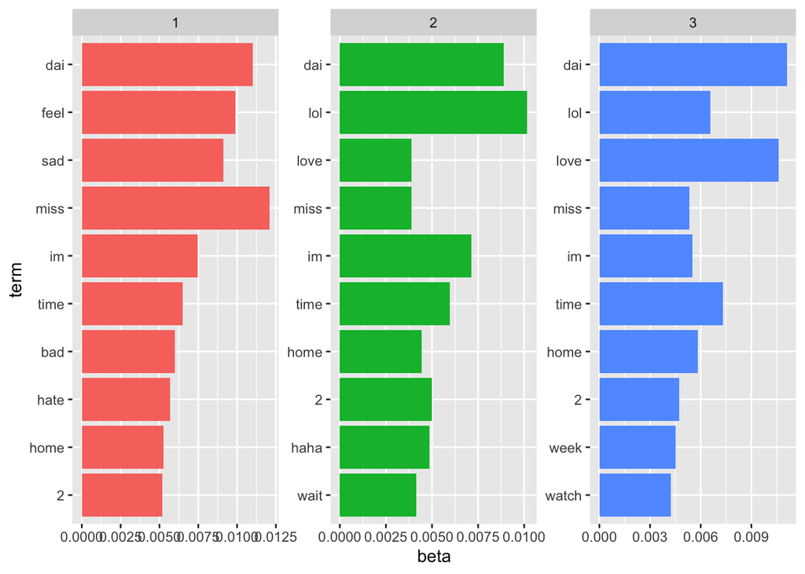

```r
lda_top_terms %>%
  mutate(term=reorder(term, beta)) %>%
  ggplot(aes(term, beta, fill=factor(topic))) +
  geom_col(show.legend = FALSE) +
  facet_wrap(~topic, scales = "free") +
  coord_flip()
```

```r
ap_lda=LDA(tweet_matrix, k=2, control=list(seed=1234))
ap_lda
```

```
## A LDA_VEM topic model with 2 topics.
```

```r
lda_topics=tidy(ap_lda, matrix="beta")
lda_topics
```

```
## # A tibble: 50,294 × 3
##    topic term       beta
##    <int> <chr>     <dbl>
##  1     1 _hayl 1.59e-  5
##  2     2 _hayl 7.82e-159
##  3     1 110   1.59e-  5
##  4     2 110   7.07e-160
##  5     1 3     3.22e-  3
##  6     2 3     3.76e-  3
##  7     1 35    1.11e-  4
##  8     2 35    8.21e-  5
##  9     1 4j585 3.17e-  5
## 10     2 4j585 7.12e-157
## # … with 50,284 more rows
```

```r
lda_top_terms = lda_topics %>%
  group_by(topic) %>%
  top_n(10, beta)%>%
  ungroup() %>%
  arrange(topic, beta)
lda_top_terms
```

```
## # A tibble: 20 × 3
##    topic term     beta
##    <int> <chr>   <dbl>
##  1     1 2     0.00500
##  2     1 hate  0.00530
##  3     1 home  0.00554
##  4     1 bad   0.00567
##  5     1 time  0.00657
##  6     1 im    0.00744
##  7     1 sad   0.00840
##  8     1 feel  0.00948
##  9     1 dai   0.0111
## 10     1 miss  0.0113
## 11     2 watch 0.00433
## 12     2 haha  0.00437
## 13     2 2     0.00497
## 14     2 home  0.00519
## 15     2 miss  0.00521
## 16     2 im    0.00571
## 17     2 time  0.00694
## 18     2 lol   0.00766
## 19     2 love  0.00975
## 20     2 dai   0.0104
```

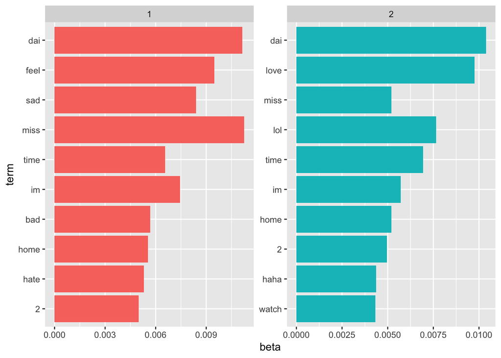

```r
lda_top_terms %>%
  mutate(term=reorder(term, beta)) %>%
  ggplot(aes(term, beta, fill=factor(topic))) +
  geom_col(show.legend = FALSE) +
  facet_wrap(~topic, scales = "free") +
  coord_flip()
```

```r
grep("dai", data1$content)
```

```
##  [1]   382  1695  1935  4233  4481  6441  6854  7707  8048  8301  9978 10402
## [13] 11360 13244 13539 14418 15200 16206 16546 16785 17609 17638 17734 17933
## [25] 18212 18926 19756
```

```r
data1$content[382]
```

```
## [1] "@crazydaisyfire Well thats even worse cuz when it gets hurt everyone is in pain, but poor Stephen has a smushed twitter now!"
```

```r
data1$content[1695]
```

```
## [1] "@daisyamy me too i hate revision"
```

```r
data1$content[1935]
```

```
## [1] "I need to get back into daily tweeting. This hiatus sucks  What also sucks is GSN interrupting shows while they're airing. &gt;_&lt;"
```

```r
data1$content[4233]
```

```
## [1] "went and got a pedicure and a manicure 2daii!!!! and den sunbathed all daii!!!! BEST DAY EVA!!!!! oh yeh,....did a teeny bit of study"
```

```r
data1$content[6441]
```

```
## [1] "Breaking the daily build broke my daily plan as well"
```

```r
data1$content[7707]
```

```
## [1] "no #thedailyshow this week"
```

```r
data1$content[9978]
```

```
## [1] "@daisydelfina my location thing? Through ubertwitter...it has an option to include locations! Jon uses uber, but he has it off  lol"
```

```r
data1$content[13244]
```

```
## [1] "I drive &gt;90mph on a daily basis. u cld film Fast &amp; Furious off of me. But anything  &lt;1 mph is not my forte'. I bump Anything!."
```

```r
data1$content[14418]
```

```
## [1] "I got up early to pay bills. I figured its like a bandaid if I get it over quickly it won't be so bad... I was wrong"
```

```r
perplexity(ap_lda)
```

```
## [1] 3760.049
```

```r
samp_size=floor(.9*nrow(tweet_matrix))
set.seed(1234)
train_i=sample(nrow(tweet_matrix), size=samp_size)
train_lda=tweet_matrix[train_i,]
test_lda=tweet_matrix[-train_i,]


values=c()
for(i in c(2:8)){
  lda_model=LDA(train_lda, k=i, control=list(seed=1234))
  values =c(values, perplexity(lda_model, newdata=test_lda))
}
```

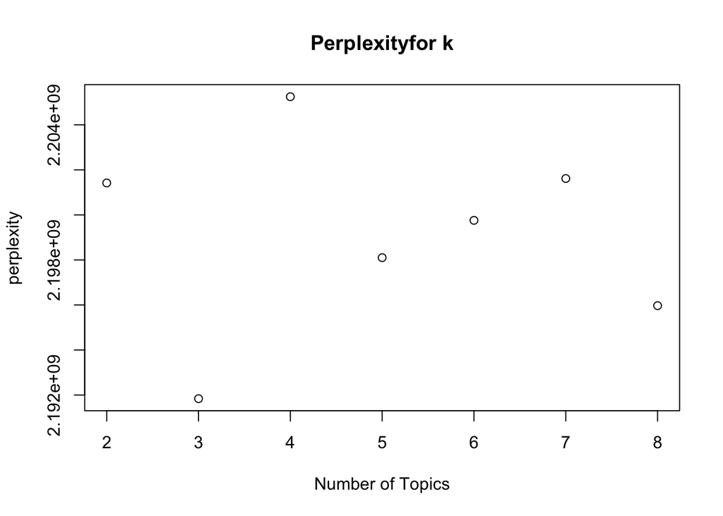

```r
plot(c(2:8), values, main="Perplexityfor k",
     xlab="Number of Topics", ylab="perplexity")
```

5. (5 points) Explain what you gained by using topic models for this data.